# STAT/MATH 495: Problem Set 03

# Rethinking the function findDF

Since LOOCV appears to underestimate the RMSE for increasing degrees of freedom, I decided to write a new function for $k=5$ fold cross validation called FiveFoldCV. As before, for this function to work, the data needs to have a 3 column format with colnames X, Y, and ID.

```r
FiveFoldCV <- function(data){
  sampleSize <- length(data1$x)/5
  set.seed(100)
  Sample1 <- data %>% sample_n(sampleSize, replace = FALSE)
  Sample2 <- data %>% setdiff(Sample1) %>% sample_n(sampleSize, replace = FALSE)
  Sample3 <- data %>% setdiff(Sample1) %>% setdiff(Sample2) %>% sample_n(sampleSize, replace = FALSE)
  Sample4 <- data %>% setdiff(Sample1) %>% setdiff(Sample2) %>% setdiff(Sample3) %>% sample_n(sampleSize, replace = FALSE)
  Sample5 <- data %>% setdiff(Sample1) %>% setdiff(Sample2) %>% setdiff(Sample3) %>% setdiff(Sample4)

  errorForDF <- rep(0, 98)

  for(i in 2:99){
  errorVect <- rep(0,5)

  tempModel1Data <- data %>% setdiff(Sample1)
  tempModel1 <- smooth.spline(tempModel1Data$x, tempModel1Data$y ,df = i)
  errorVect[1] <- sum((Sample1$y - predict(tempModel1, Sample1$x)$y)^2)

  tempModel2Data <- data %>% setdiff(Sample2)
  tempModel2 <- smooth.spline(tempModel2Data$x, tempModel2Data$y ,df = i)
  errorVect[2] <- sum((Sample2$y - predict(tempModel2, Sample2$x)$y)^2)

  tempModel3Data <- data %>% setdiff(Sample3)
  tempModel3 <- smooth.spline(tempModel3Data$x, tempModel3Data$y ,df = i)
  errorVect[3] <- sum((Sample3$y - predict(tempModel3, Sample3$x)$y)^2)

  tempModel4Data <- data %>% setdiff(Sample4)
  tempModel4 <- smooth.spline(tempModel4Data$x, tempModel4Data$y ,df = i)
  errorVect[4] <- sum((Sample4$y - predict(tempModel4, Sample4$x)$y)^2)

  tempModel5Data <- data %>% setdiff(Sample5)
  tempModel5 <- smooth.spline(tempModel5Data$x, tempModel5Data$y ,df = i)
  errorVect[5] <- sum((Sample5$y - predict(tempModel5, Sample5$x)$y)^2)

  errorCurr <- sqrt(sum(errorVect)/length(data1$x))

  errorForDF[i-1] <- errorCurr
  }

  return(errorForDF)
}
```

# K=5 Cross Validation for Data1

Running $K=5$ CV for Data1, I found a curve of the expected form: decreasing and then increasing RMSE as the degrees of freedom increases. I’ve plotted the splines model for the minimum RMSE found at $df=33$.

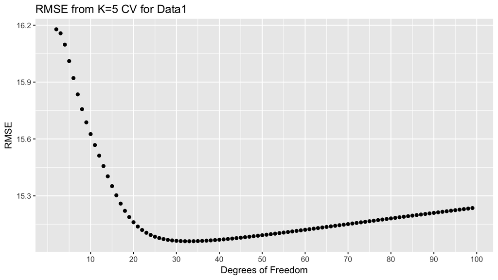

```r
errorTableData1FiveFold <- FiveFoldCV(data1)
DF <- c(2:99)
RMSEData1FiveFold <- data.frame(errorTableData1FiveFold, DF)
ggplot(RMSEData1FiveFold, aes(DF, errorTableData1FiveFold)) +
  geom_point() +
  scale_x_continuous(breaks=c(10, 20, 30, 40, 50, 60, 70, 80, 90, 100)) +
  labs(title = "RMSE from K=5 CV for Data1", x = "Degrees of Freedom", y = "RMSE")
```

```r
print(RMSEData1FiveFold[RMSEData1FiveFold$errorTableData1FiveFold == min(RMSEData1FiveFold$errorTableData1FiveFold),])
```

```
##    errorTableData1FiveFold DF
## 32                15.06051 33
```

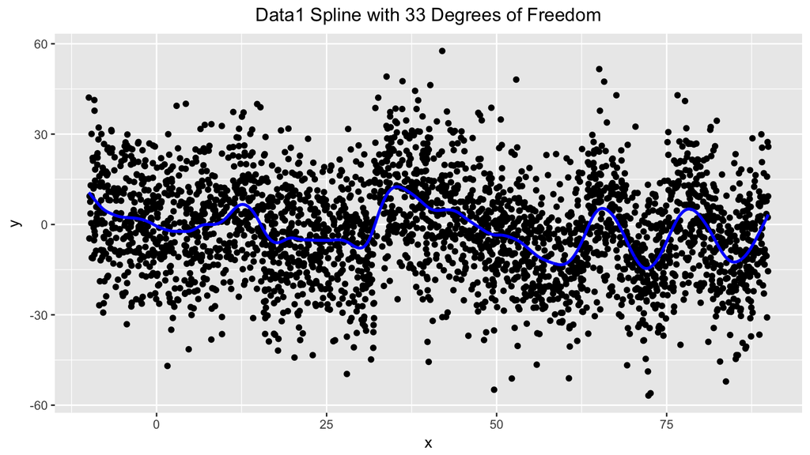

```r
thirty3 <- smooth.spline(data1$x, data1$y, df=33) %>%
  broom::augment() %>%
  ggplot(aes(x = data1$x)) +
  geom_point(aes(y = data1$y)) +
  geom_line(aes(y=.fitted), col="blue", size=1) +
  labs(title = "Data1 Spline with 33 Degrees of Freedom", x = "x", y = "y") +
  theme(plot.title = element_text(hjust = 0.5))
thirty3
```